# BELLABEAT CASE STUDY

Nicholas Newdorf

2022-09-24

## THE TASK

Determine suggestions for Bellabeat marketing by analyzing current trends in other smart trackers.

- What current Bellabeat offerings match user trends?
- Are there deficiencies in the current line up?

## THE DATA

A data set was sourced over the course of a month from 33 Fitbit users

### Data Limitations

- Only 33 participants in the study
- Bellabeat caters to a female audience, the gender of Fitbit users is unknown
- There is variance in the Fitbit types leading to subsets of participants for some metrics

### Data Cleaning Process

72 rows with 0 steps and 1440 sedentary minutes were removed under the assumption that this indicated days the device was not worn

## THE ANALYSIS

### Time Spent Measuring Throughout The Day

Not all devices are used for a full 24 hour day. Some participants never hit a full day while others did so consistently. Participants seem to congregate at either one extreme or another with few in between.

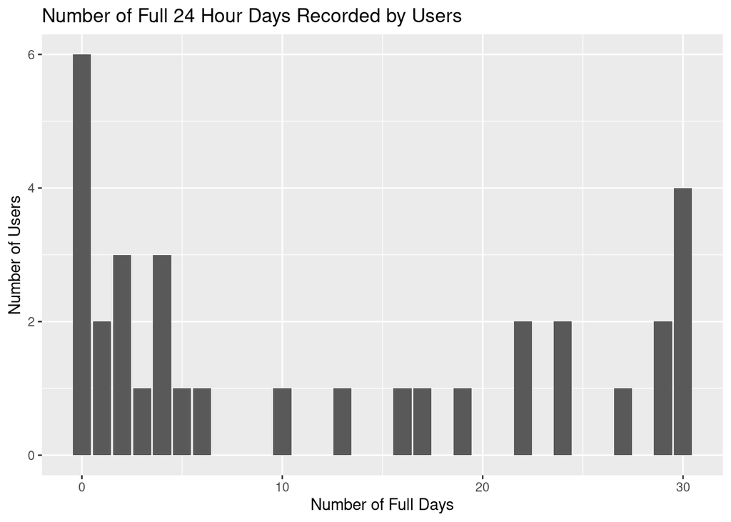

### Types of Activities

Activities are measured in four groups: Sedentary, Lightly Active, Fairly Active, and Very Active. Sedentary activity is by far the most measured activity.

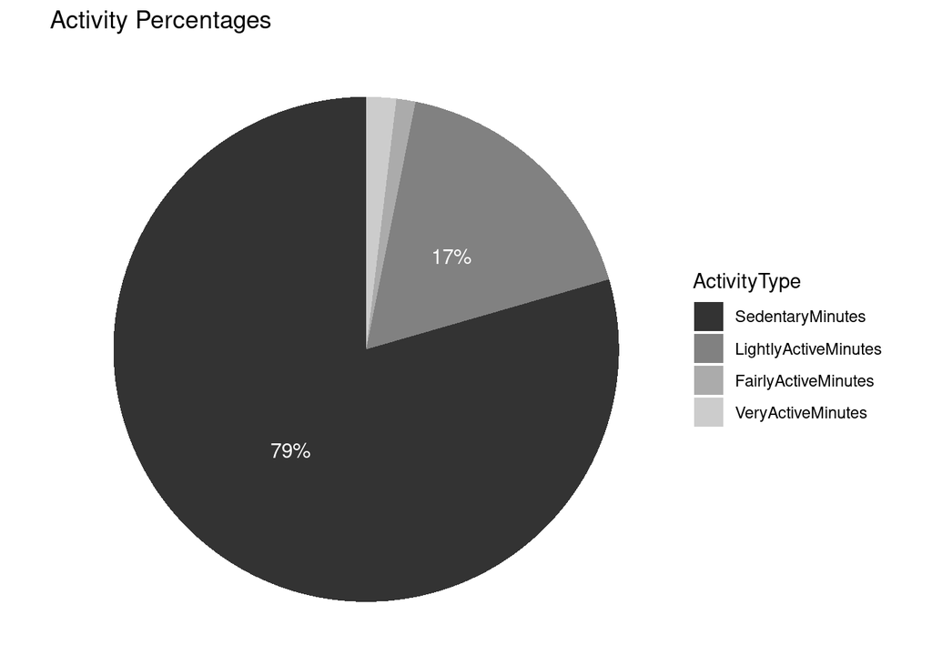

### Types of Metrics

There are multiple metrics that can be tracked by FitBits, some are more tracked than others.

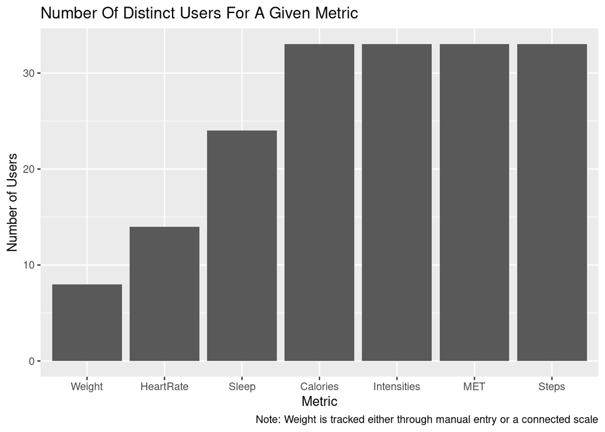

## CONCLUSION

### Key Findings

- The uses of current smart trackers vary:
  - Most of the time users are sedentary with small bursts of higher intensity activity.
  - Sleep tracking and activity tracking are widely used while fewer people track heart-rate and weight.
- Metrics that require manual input (like weight) appear to be less widely used than those automatically tracked.

### Recomendation

Out of Bellabeat’s current lineup, the Leaf most closely resembles the data tracked in this data set. The Ivy includes extra features that some might use such as heart-rate tracking, but that accounts for less than half the participants of the study. For this purpose, it is my recommendation that we focus marketing on the Leaf.

### Future Analysis Opportunities

This study focused on a small set of Fitbit users and had many data limitations. Finding bigger data sets that more closely resemble Bellabeat’s clientele would provide a better picture of the smart tracker landscape.

## APPENDIX

Dataset taken from: https://www.kaggle.com/datasets/arashnic/fitbit/

Data dictionary from: https://www.fitabase.com/media/1930/fitabasedatadictionary102320.pdf

Differences between Leaf and Ivy: https://support.bellabeat.com/hc/en-us/articles/360020587680-What-is-the-difference-between-Ivy-and-the-Leaf-